# COM747 Week 5: Supervised Machine Learning and Feature Engineering

Lecture demonstrations and complete seminar solutions

> **How to use this notebook.** Part A demonstrates the lecture ideas (overfitting, k-NN, decision trees, cross-validation). Part B completes every task on the seminar sheet `Exercise(2).pdf`, including all the “additional tasks”, plus the confusion-matrix tutorial. Put `Iris.csv` and `data.csv` in the same folder.

```r
library(class)     # knn()
library(gmodels)   # CrossTable()
library(C50)       # C5.0() decision trees
library(rpart)     # rpart() trees (for plotting)
library(Boruta)    # Boruta() feature selection
library(caret)     # createDataPartition(), confusionMatrix()
```

```r
# A small helper used throughout: metrics from a 2 x 2 confusion table.
# 'positive' is the class we are trying to detect (e.g. "M" for malignant).
metrics <- function(predicted, actual, positive) {
  TP <- sum(predicted == positive & actual == positive)
  TN <- sum(predicted != positive & actual != positive)
  FP <- sum(predicted == positive & actual != positive)
  FN <- sum(predicted != positive & actual == positive)
  c(accuracy    = (TP + TN) / (TP + TN + FP + FN),
    sensitivity = TP / (TP + FN),
    specificity = TN / (TN + FP),
    precision   = TP / (TP + FP),
    F1          = 2 * TP / (2 * TP + FP + FN))
}
```

# Part A: Lecture demonstrations

## 1. Overfitting: training error vs test error

```r
set.seed(3)
x  <- runif(40); y <- sin(2 * pi * x) + rnorm(40, 0, 0.3)   # a curved pattern plus noise
train <- data.frame(x = x[1:20],  y = y[1:20])
test  <- data.frame(x = x[21:40], y = y[21:40])

errs <- t(sapply(1:12, function(d) {
  m <- lm(y ~ poly(x, d, raw = FALSE), data = train)       # polynomial of degree d
  c(train = mean((predict(m, train) - train$y)^2),
    test  = mean((predict(m, test)  - test$y)^2))
}))
round(errs, 3)
```

```
##       train     test
##  [1,] 0.125    0.316
##  [2,] 0.122    0.337
##  [3,] 0.058    0.095
##  [4,] 0.057    0.104
##  [5,] 0.046    0.724
##  [6,] 0.044    0.205
##  [7,] 0.042    1.746
##  [8,] 0.033   30.883
##  [9,] 0.031  103.668
## [10,] 0.021   70.209
## [11,] 0.015 1220.188
## [12,] 0.015  992.034
```

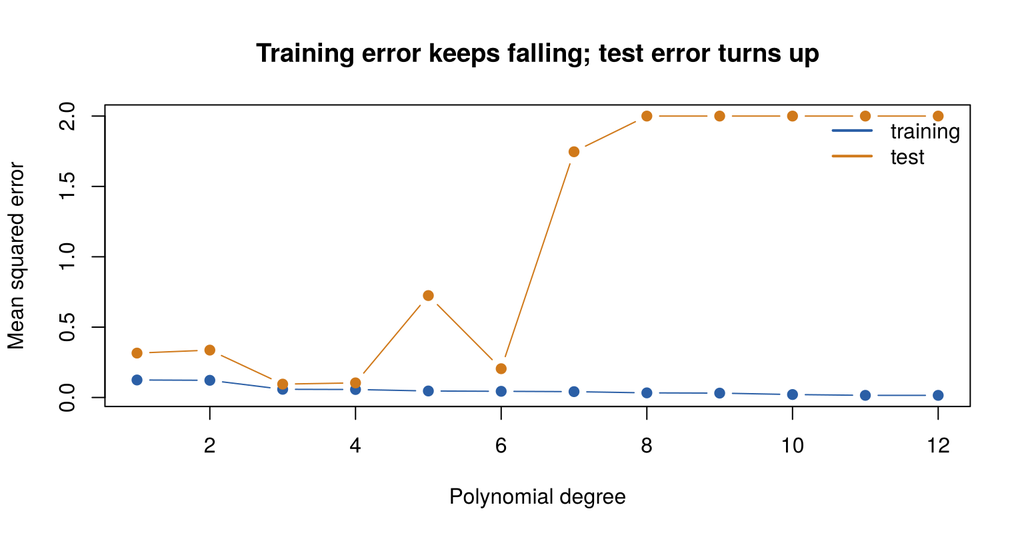

```r
matplot(1:12, pmin(errs, 2), type = "b", pch = 19, lty = 1, col = c("#2b5fa6", "#d0791a"),
        xlab = "Polynomial degree", ylab = "Mean squared error", main = "Training error keeps falling; test error turns up")
legend("topright", c("training", "test"), col = c("#2b5fa6", "#d0791a"), lwd = 2, bty = "n")
```

**Ask:** Which degree would you choose? (The one with the lowest *test* error, not the lowest training error.)

## 2. k-NN by hand

```r
# Euclidean distance between two flowers described by 4 measurements
euclidean <- function(a, b) sqrt(sum((a - b)^2))
new_flower <- c(5.9, 3.0, 4.9, 1.6)
d <- apply(iris[, 1:4], 1, euclidean, b = new_flower)   # distance to all 150 flowers
nearest <- order(d)[1:3]                                # the 3 closest
iris[nearest, ]
```

```
##     Sepal.Length Sepal.Width Petal.Length Petal.Width   Species
## 139          6.0           3          4.8         1.8 virginica
## 128          6.1           3          4.9         1.8 virginica
## 150          5.9           3          5.1         1.8 virginica
```

```r
table(iris$Species[nearest])                            # majority vote = prediction
```

```
##
##     setosa versicolor  virginica
##          0          0          3
```

## 3. Entropy and information gain

```r
entropy <- function(labels) { p <- prop.table(table(labels)); -sum(p * log2(p)) }
info_gain <- function(feature, labels, threshold) {
  left <- labels[feature <= threshold]; right <- labels[feature > threshold]
  entropy(labels) - (length(left) * entropy(left) + length(right) * entropy(right)) / length(labels)
}
data <- read.csv("data.csv")
entropy(data$diagnosis)                                    # before any split
```

```
## [1] 0.9526351
```

```r
info_gain(data$concave.points_worst, data$diagnosis, 0.14) # a strong split
```

```
## [1] 0.5233097
```

```r
info_gain(data$texture_mean,         data$diagnosis, 20)   # a weak split
```

```
## [1] 0.1364086
```

## 4. k-fold cross-validation by hand

```r
set.seed(1)
iris_s <- iris[sample(nrow(iris)), ]
iris_s[, 1:4] <- scale(iris_s[, 1:4])
folds <- cut(seq_len(nrow(iris_s)), breaks = 10, labels = FALSE)   # 10 folds of 15 flowers
acc <- sapply(1:10, function(f) {
  test_idx <- which(folds == f)
  pred <- knn(iris_s[-test_idx, 1:4], iris_s[test_idx, 1:4], iris_s$Species[-test_idx], k = 5)
  mean(pred == iris_s$Species[test_idx])
})
round(acc, 3)
```

```
##  [1] 0.933 0.933 1.000 0.867 0.933 0.933 1.000 1.000 0.933 0.933
```

```r
c(mean = mean(acc), se = sd(acc) / sqrt(10))   # report the mean +/- standard error
```

```
##       mean         se
## 0.94666667 0.01333333
```

# Part B: Seminar exercises (complete solutions)

## Exercise 1: k-NN on the iris data

```r
Iris <- read.csv("Iris.csv")     # Kaggle version: Id, SepalLengthCm, ..., Species
head(Iris)
```

```
##   Id SepalLengthCm SepalWidthCm PetalLengthCm PetalWidthCm     Species
## 1  1           5.1          3.5           1.4          0.2 Iris-setosa
## 2  2           4.9          3.0           1.4          0.2 Iris-setosa
## 3  3           4.7          3.2           1.3          0.2 Iris-setosa
## 4  4           4.6          3.1           1.5          0.2 Iris-setosa
## 5  5           5.0          3.6           1.4          0.2 Iris-setosa
## 6  6           5.4          3.9           1.7          0.4 Iris-setosa
```

```r
set.seed(1)   # reproducible shuffle
# sample(nrow(Iris)) returns the row numbers 1..150 in random order;
# columns 2:6 drop the Id column, which carries no information about the species.
IrisData <- Iris[sample(nrow(Iris), replace = FALSE), c(2, 3, 4, 5, 6)]
IrisData$Species <- factor(IrisData$Species)   # classification needs a factor label
table(IrisData$Species)
```

```
##
##     Iris-setosa Iris-versicolor  Iris-virginica
##              50              50              50
```

```r
prop.table(table(IrisData$Species))            # balanced: one third each
```

```
##
##     Iris-setosa Iris-versicolor  Iris-virginica
##       0.3333333       0.3333333       0.3333333
```

```r
# Standardise each measurement: mean 0, SD 1, so no feature dominates the distance
IrisData$SepalLengthCm <- as.numeric(scale(IrisData$SepalLengthCm))
IrisData$SepalWidthCm  <- as.numeric(scale(IrisData$SepalWidthCm))
IrisData$PetalLengthCm <- as.numeric(scale(IrisData$PetalLengthCm))
IrisData$PetalWidthCm  <- as.numeric(scale(IrisData$PetalWidthCm))
round(mean(IrisData$SepalLengthCm)); round(sd(IrisData$SepalLengthCm))   # 0 and 1
```

```
## [1] 0
```

```
## [1] 1
```

```r
# Features (columns 1-4) and labels (column 5) are passed to knn() separately
trainingData   <- IrisData[1:100, 1:4]
testData       <- IrisData[101:150, 1:4]
trainingLabels <- IrisData[1:100, 5]
testingLabels  <- IrisData[101:150, 5]

knnModelAndPredictedLabels <- knn(train = trainingData, test = testData, cl = trainingLabels, k = 3)
table(testingLabels, knnModelAndPredictedLabels)
```

```
##                  knnModelAndPredictedLabels
## testingLabels     Iris-setosa Iris-versicolor Iris-virginica
##   Iris-setosa              16               0              0
##   Iris-versicolor           0              19              0
##   Iris-virginica            0               1             14
```

```r
CrossTable(x = testingLabels, y = knnModelAndPredictedLabels, prop.chisq = FALSE)
```

```
##
##
##    Cell Contents
## |-------------------------|
## |                       N |
## |           N / Row Total |
## |           N / Col Total |
## |         N / Table Total |
## |-------------------------|
##
##
## Total Observations in Table:  50
##
##
##                 | knnModelAndPredictedLabels
##   testingLabels |     Iris-setosa | Iris-versicolor |  Iris-virginica |       Row Total |
## ----------------|-----------------|-----------------|-----------------|-----------------|
##     Iris-setosa |              16 |               0 |               0 |              16 |
##                 |           1.000 |           0.000 |           0.000 |           0.320 |
##                 |           1.000 |           0.000 |           0.000 |                 |
##                 |           0.320 |           0.000 |           0.000 |                 |
## ----------------|-----------------|-----------------|-----------------|-----------------|
## Iris-versicolor |               0 |              19 |               0 |              19 |
##                 |           0.000 |           1.000 |           0.000 |           0.380 |
##                 |           0.000 |           0.950 |           0.000 |                 |
##                 |           0.000 |           0.380 |           0.000 |                 |
## ----------------|-----------------|-----------------|-----------------|-----------------|
##  Iris-virginica |               0 |               1 |              14 |              15 |
##                 |           0.000 |           0.067 |           0.933 |           0.300 |
##                 |           0.000 |           0.050 |           1.000 |                 |
##                 |           0.000 |           0.020 |           0.280 |                 |
## ----------------|-----------------|-----------------|-----------------|-----------------|
##    Column Total |              16 |              20 |              14 |              50 |
##                 |           0.320 |           0.400 |           0.280 |                 |
## ----------------|-----------------|-----------------|-----------------|-----------------|
##
##
```

### Additional task 1: accuracy

```r
accuracy <- mean(knnModelAndPredictedLabels == testingLabels)   # correct / total
accuracy
```

```
## [1] 0.98
```

```r
# equivalently: sum(diag(table(...))) / sum(table(...))
```

### Additional task 2: a 90/10 split

```r
pred90 <- knn(IrisData[1:135, 1:4], IrisData[136:150, 1:4], IrisData[1:135, 5], k = 3)
table(IrisData[136:150, 5], pred90)
```

```
##                  pred90
##                   Iris-setosa Iris-versicolor Iris-virginica
##   Iris-setosa               6               0              0
##   Iris-versicolor           0               6              0
##   Iris-virginica            0               1              2
```

```r
mean(pred90 == IrisData[136:150, 5])
```

```
## [1] 0.9333333
```

With only 15 test flowers, each mistake costs 6.7 percentage points. More training data helps the model, but a tiny test set gives a very noisy estimate. Cross-validation (Part A, section 4) gets the best of both.

### Additional tasks 3 and 4: different k, and a plot

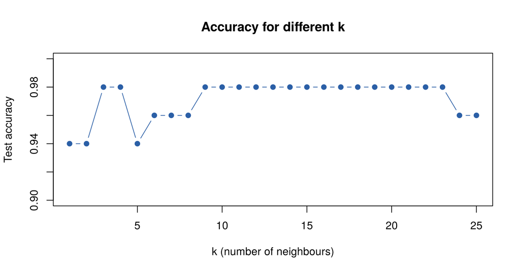

```r
ks  <- 1:25
acc <- sapply(ks, function(k) {
  set.seed(1)   # knn breaks ties at random; fixing the seed makes the curve reproducible
  mean(knn(trainingData, testData, trainingLabels, k = k) == testingLabels)
})
plot(ks, acc, type = "b", pch = 19, col = "#2b5fa6", ylim = c(0.9, 1),
     xlab = "k (number of neighbours)", ylab = "Test accuracy", main = "Accuracy for different k")
```

```r
ks[which.max(acc)]   # the first k with the best accuracy
```

```
## [1] 3
```

### Additional task 5: a balanced test set

```r
# createDataPartition samples WITHIN each class, so train and test keep the same class mix
set.seed(1)
idx <- createDataPartition(IrisData$Species, p = 2/3, list = FALSE)
table(IrisData$Species[-idx])   # test set: equal numbers of each species
```

```
##
##     Iris-setosa Iris-versicolor  Iris-virginica
##              16              16              16
```

```r
predS <- knn(IrisData[idx, 1:4], IrisData[-idx, 1:4], IrisData$Species[idx], k = 3)
mean(predS == IrisData$Species[-idx])
```

```
## [1] 0.8958333
```

### Additional task 6: min-max normalisation instead of standardisation

```r
normalisation <- function(x) (x - min(x)) / (max(x) - min(x))   # rescale to 0..1
set.seed(1)
IrisNorm <- Iris[sample(nrow(Iris)), 2:6]
IrisNorm[, 1:4] <- lapply(IrisNorm[, 1:4], normalisation)
summary(IrisNorm[, 1:4])                                        # every feature now 0..1
```

```
##  SepalLengthCm     SepalWidthCm    PetalLengthCm     PetalWidthCm
##  Min.   :0.0000   Min.   :0.0000   Min.   :0.0000   Min.   :0.00000
##  1st Qu.:0.2222   1st Qu.:0.3333   1st Qu.:0.1017   1st Qu.:0.08333
##  Median :0.4167   Median :0.4167   Median :0.5678   Median :0.50000
##  Mean   :0.4287   Mean   :0.4406   Mean   :0.4675   Mean   :0.45806
##  3rd Qu.:0.5833   3rd Qu.:0.5417   3rd Qu.:0.6949   3rd Qu.:0.70833
##  Max.   :1.0000   Max.   :1.0000   Max.   :1.0000   Max.   :1.00000
```

```r
predN <- knn(IrisNorm[1:100, 1:4], IrisNorm[101:150, 1:4], factor(IrisNorm$Species[1:100]), k = 3)
mean(predN == IrisNorm$Species[101:150])
```

```
## [1] 0.98
```

## Exercise 2: k-NN on the breast cancer data (Lantz, chapter 3)

```r
data <- read.csv("data.csv")
dim(data)                  # 569 rows; the last column "X" is empty (a trailing comma in the CSV)
```

```
## [1] 569  33
```

```r
data <- data[, 2:32]       # drop id (meaningless for prediction) and the empty X column
data$diagnosis <- factor(data$diagnosis, levels = c("B", "M"), labels = c("Benign", "Malignant"))
round(prop.table(table(data$diagnosis)) * 100, 1)
```

```
##
##    Benign Malignant
##      62.7      37.3
```

```r
summary(data[c("radius_mean", "area_mean", "smoothness_mean")])   # very different scales
```

```
##   radius_mean       area_mean      smoothness_mean
##  Min.   : 6.981   Min.   : 143.5   Min.   :0.05263
##  1st Qu.:11.700   1st Qu.: 420.3   1st Qu.:0.08637
##  Median :13.370   Median : 551.1   Median :0.09587
##  Mean   :14.127   Mean   : 654.9   Mean   :0.09636
##  3rd Qu.:15.780   3rd Qu.: 782.7   3rd Qu.:0.10530
##  Max.   :28.110   Max.   :2501.0   Max.   :0.16340
```

```r
data_n <- as.data.frame(lapply(data[2:31], normalisation))   # normalise all 30 features
set.seed(1)
shuffle <- sample(nrow(data_n))
train_x <- data_n[shuffle[1:469], ];   test_x <- data_n[shuffle[470:569], ]
train_y <- data$diagnosis[shuffle[1:469]]; test_y <- data$diagnosis[shuffle[470:569]]
pred <- knn(train_x, test_x, train_y, k = 21)   # Lantz uses k = 21 (about sqrt(469))
CrossTable(test_y, pred, prop.chisq = FALSE)
```

```
##
##
##    Cell Contents
## |-------------------------|
## |                       N |
## |           N / Row Total |
## |           N / Col Total |
## |         N / Table Total |
## |-------------------------|
##
##
## Total Observations in Table:  100
##
##
##              | pred
##       test_y |    Benign | Malignant | Row Total |
## -------------|-----------|-----------|-----------|
##       Benign |        60 |         1 |        61 |
##              |     0.984 |     0.016 |     0.610 |
##              |     0.896 |     0.030 |           |
##              |     0.600 |     0.010 |           |
## -------------|-----------|-----------|-----------|
##    Malignant |         7 |        32 |        39 |
##              |     0.179 |     0.821 |     0.390 |
##              |     0.104 |     0.970 |           |
##              |     0.070 |     0.320 |           |
## -------------|-----------|-----------|-----------|
## Column Total |        67 |        33 |       100 |
##              |     0.670 |     0.330 |           |
## -------------|-----------|-----------|-----------|
##
##
```

```r
metrics(pred, test_y, positive = "Malignant")
```

```
##    accuracy sensitivity specificity   precision          F1
##   0.9200000   0.8205128   0.9836066   0.9696970   0.8888889
```

**Which mistakes matter?** A false negative (malignant called benign) is far worse than a false positive here. When comparing models for diagnosis, prioritise **sensitivity**, not just accuracy.

## Exercise 3: decision trees with C5.0

```r
data <- read.csv("data.csv")
set.seed(1)
DataDF <- data[sample(nrow(data), replace = FALSE), c(2:32)]   # shuffle; keep diagnosis + 30 features
DataDF$diagnosis <- factor(DataDF$diagnosis)
table(DataDF$diagnosis)                  # imbalanced: 357 B, 212 M
```

```
##
##   B   M
## 357 212
```

```r
trainingDataDT <- DataDF[1:500, ]        # ~88% train
testDataDT     <- DataDF[501:569, ]      # ~12% test

decisionTree <- C5.0(diagnosis ~ ., data = trainingDataDT)
summary(decisionTree)                    # the rules, and attribute usage (% of training cases using each feature)
```

```
##
## Call:
## C5.0.formula(formula = diagnosis ~ ., data = trainingDataDT)
##
##
## C5.0 [Release 2.07 GPL Edition]
## -------------------------------
##
## Class specified by attribute `outcome'
##
## Read 500 cases (31 attributes) from undefined.data
##
## Decision tree:
##
## perimeter_worst > 115:
## :...concave.points_worst > 0.1155: M (140)
## :   concave.points_worst <= 0.1155:
## :   :...texture_mean <= 19.83: B (3)
## :       texture_mean > 19.83: M (5)
## perimeter_worst <= 115:
## :...concave.points_worst <= 0.1108:
##     :...area_se <= 38.87: B (262/1)
##     :   area_se > 38.87:
##     :   :...radius_mean <= 14.96: B (11/1)
##     :       radius_mean > 14.96: M (3)
##     concave.points_worst > 0.1108:
##     :...concave.points_worst > 0.1599: M (18/1)
##         concave.points_worst <= 0.1599:
##         :...area_worst <= 767.3:
##             :...texture_worst <= 33.22: B (29)
##             :   texture_worst > 33.22: M (2)
##             area_worst > 767.3:
##             :...texture_worst <= 20.07: B (7)
##                 texture_worst > 20.07:
##                 :...smoothness_mean > 0.09009: M (14/1)
##                     smoothness_mean <= 0.09009:
##                     :...compactness_worst <= 0.2536: M (2)
##                         compactness_worst > 0.2536: B (4)
##
##
```

[output cut: 11 more lines]

```
##     314     2    (a): class B
##       2   182    (b): class M
##
##
##  Attribute usage:
##
##  100.00% perimeter_worst
##  100.00% concave.points_worst
##   55.20% area_se
##   11.60% texture_worst
##   11.60% area_worst
##    4.00% smoothness_mean
##    2.80% radius_mean
##    1.60% texture_mean
##    1.20% compactness_worst
```

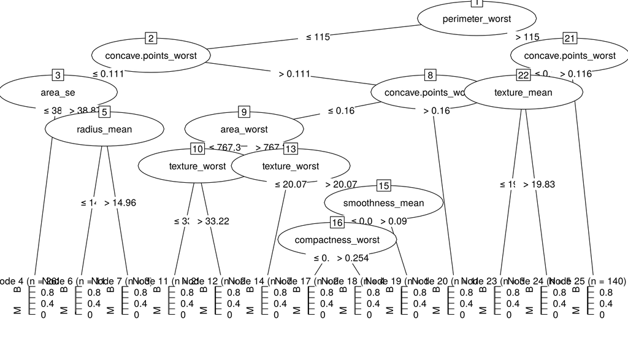

```r
plot(decisionTree)
```

```r
decisionTreePredictions <- predict(decisionTree, testDataDT)
table(decisionTreePredictions, testDataDT$diagnosis)
```

```
##
## decisionTreePredictions  B  M
##                       B 40  2
##                       M  1 26
```

```r
CrossTable(x = decisionTreePredictions, y = testDataDT$diagnosis, prop.chisq = FALSE)
```

```
##
##
##    Cell Contents
## |-------------------------|
## |                       N |
## |           N / Row Total |
## |           N / Col Total |
## |         N / Table Total |
## |-------------------------|
##
##
## Total Observations in Table:  69
##
##
##                         | testDataDT$diagnosis
## decisionTreePredictions |         B |         M | Row Total |
## ------------------------|-----------|-----------|-----------|
##                       B |        40 |         2 |        42 |
##                         |     0.952 |     0.048 |     0.609 |
##                         |     0.976 |     0.071 |           |
##                         |     0.580 |     0.029 |           |
## ------------------------|-----------|-----------|-----------|
##                       M |         1 |        26 |        27 |
##                         |     0.037 |     0.963 |     0.391 |
##                         |     0.024 |     0.929 |           |
##                         |     0.014 |     0.377 |           |
## ------------------------|-----------|-----------|-----------|
##            Column Total |        41 |        28 |        69 |
##                         |     0.594 |     0.406 |           |
## ------------------------|-----------|-----------|-----------|
##
##
```

```r
metrics(decisionTreePredictions, testDataDT$diagnosis, positive = "M")
```

```
##    accuracy sensitivity specificity   precision          F1
##   0.9565217   0.9285714   0.9756098   0.9629630   0.9454545
```

### Boosting

```r
boosted <- C5.0(diagnosis ~ ., data = trainingDataDT, trials = 10)   # 10 trees vote
boostedPred <- predict(boosted, testDataDT)
table(boostedPred, testDataDT$diagnosis)
```

```
##
## boostedPred  B  M
##           B 39  2
##           M  2 26
```

```r
metrics(boostedPred, testDataDT$diagnosis, positive = "M")
```

```
##    accuracy sensitivity specificity   precision          F1
##   0.9420290   0.9285714   0.9512195   0.9285714   0.9285714
```

On this particular test set boosting is no better (one extra false alarm). With 69 test cases, one case moves accuracy by 1.4 points, so this comparison is too small to conclude anything. Compare models with cross-validation instead (see the different-splits task and Week 7).

### Additional task: different train/test splits

```r
split_result <- function(p) {
  n_train <- round(569 * p)                          # e.g. 569 * 0.7 = 398
  tr <- DataDF[1:n_train, ]; te <- DataDF[(n_train + 1):569, ]
  pr <- predict(C5.0(diagnosis ~ ., data = tr), te)
  round(c(train_size = n_train, metrics(pr, te$diagnosis, "M")), 3)
}
t(sapply(c(0.8, 0.7, 0.6), split_result))
```

```
##      train_size accuracy sensitivity specificity precision    F1
## [1,]        455    0.895       0.837       0.930     0.878 0.857
## [2,]        398    0.930       0.926       0.932     0.900 0.913
## [3,]        341    0.912       0.874       0.940     0.912 0.892
```

### Additional task: rebalance the classes

```r
B <- trainingDataDT[trainingDataDT$diagnosis == "B", ]
M <- trainingDataDT[trainingDataDT$diagnosis == "M", ]
set.seed(1)
M_over   <- M[sample(nrow(M), nrow(B), replace = TRUE), ]   # oversample M up to the size of B
balanced <- rbind(B, M_over)
table(balanced$diagnosis)                                  # now equal
```

```
##
##   B   M
## 316 316
```

```r
balPred <- predict(C5.0(diagnosis ~ ., data = balanced), testDataDT)
metrics(balPred, testDataDT$diagnosis, "M")
```

```
##    accuracy sensitivity specificity   precision          F1
##   0.9130435   0.9285714   0.9024390   0.8666667   0.8965517
```

### Additional task: feature selection with t-tests (filter method)

```r
features <- names(trainingDataDT)[-1]
pvals <- sapply(features, function(f) t.test(trainingDataDT[[f]] ~ trainingDataDT$diagnosis)$p.value)
sort(signif(pvals, 3))[1:10]                 # most significant features
```

```
## concave.points_worst      perimeter_worst  concave.points_mean
##             4.55e-86             2.55e-63             1.05e-62
##         radius_worst       perimeter_mean          radius_mean
##             4.69e-62             4.38e-59             3.69e-57
##       concavity_mean      concavity_worst           area_worst
##             4.09e-51             8.03e-51             2.37e-47
##            area_mean
##             4.29e-47
```

```r
keep <- names(pvals)[pvals < 0.001]          # strict threshold (many tests, so be strict)
length(keep)
```

```
## [1] 25
```

```r
filtered <- C5.0(x = trainingDataDT[, keep], y = trainingDataDT$diagnosis)
metrics(predict(filtered, testDataDT[, keep]), testDataDT$diagnosis, "M")
```

```
##    accuracy sensitivity specificity   precision          F1
##   0.9565217   0.9285714   0.9756098   0.9629630   0.9454545
```

The t-tests use the **training set only**. Choosing features using the test set would leak information and make the test accuracy look better than it really is.

### Additional task: Boruta

```r
set.seed(1)
borutaFeatureSelectionMethod <- Boruta(diagnosis ~ ., data = trainingDataDT)
print(borutaFeatureSelectionMethod)
```

```
## Boruta performed 99 iterations in 12.60348 secs.
##  27 attributes confirmed important: area_mean, area_se, area_worst,
## compactness_mean, compactness_se and 22 more;
##  1 attributes confirmed unimportant: smoothness_se;
##  2 tentative attributes left: symmetry_se, texture_se;
```

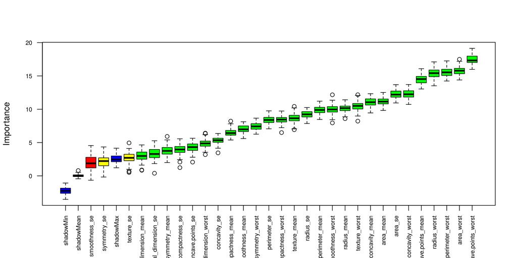

```r
plot(borutaFeatureSelectionMethod, las = 2, cex.axis = 0.7, xlab = "")
```

```r
getSelectedAttributes(borutaFeatureSelectionMethod)   # confirmed features
```

```
##  [1] "radius_mean"             "texture_mean"
##  [3] "perimeter_mean"          "area_mean"
##  [5] "smoothness_mean"         "compactness_mean"
##  [7] "concavity_mean"          "concave.points_mean"
##  [9] "symmetry_mean"           "fractal_dimension_mean"
## [11] "radius_se"               "perimeter_se"
## [13] "area_se"                 "compactness_se"
## [15] "concavity_se"            "concave.points_se"
## [17] "fractal_dimension_se"    "radius_worst"
## [19] "texture_worst"           "perimeter_worst"
## [21] "area_worst"              "smoothness_worst"
## [23] "compactness_worst"       "concavity_worst"
## [25] "concave.points_worst"    "symmetry_worst"
## [27] "fractal_dimension_worst"
```

```r
attStats(borutaFeatureSelectionMethod)[order(-attStats(borutaFeatureSelectionMethod)$medianImp), ][1:8, ]
```

```
##                       meanImp medianImp   minImp   maxImp normHits  decision
## concave.points_worst 17.44874  17.32632 15.98859 19.13740        1 Confirmed
## area_worst           15.78746  15.78484 14.39584 17.48909        1 Confirmed
## perimeter_worst      15.54142  15.53653 14.23888 17.25791        1 Confirmed
## radius_worst         15.37944  15.41549 13.51742 17.10749        1 Confirmed
## concave.points_mean  14.49843  14.52874 13.03959 16.08142        1 Confirmed
## concavity_worst      12.27168  12.24575 10.72069 13.70912        1 Confirmed
## area_se              12.25583  12.19840 10.94186 13.68533        1 Confirmed
## area_mean            11.15459  11.14303  9.82296 12.52024        1 Confirmed
```

## Exercise 4: confusion matrix tutorial

```r
TP <- 102; FN <- 22; FP <- 9; TN <- 150     # read from the matrix in the tutorial
c(A_true_positives = TP,
  B_true_negatives = TN,
  C_accuracy       = (TP + TN) / (TP + TN + FP + FN),
  D_sensitivity    = TP / (TP + FN),
  E_specificity    = TN / (TN + FP),
  F_F1             = 2 * TP / (2 * TP + FP + FN),
  G_type_I_errors  = FP)
```

```
## A_true_positives B_true_negatives       C_accuracy    D_sensitivity
##      102.0000000      150.0000000        0.8904594        0.8225806
##    E_specificity             F_F1  G_type_I_errors
##        0.9433962        0.8680851        9.0000000
```

These match the answers on the sheet: 102, 150, 0.890, 0.823, 0.943, 0.868 and 9.

## Exercise 5: caret (a first look)

```r
set.seed(1)
idx <- createDataPartition(DataDF$diagnosis, p = 0.7, list = FALSE)
fit <- train(diagnosis ~ ., data = DataDF[idx, ], method = "knn",
             preProcess = c("center", "scale"),                  # standardise inside caret
             trControl = trainControl(method = "cv", number = 10))
fit
```

```
## k-Nearest Neighbors
##
## 399 samples
##  30 predictor
##   2 classes: 'B', 'M'
##
## Pre-processing: centered (30), scaled (30)
## Resampling: Cross-Validated (10 fold)
## Summary of sample sizes: 359, 359, 359, 359, 359, 359, ...
## Resampling results across tuning parameters:
##
##   k  Accuracy   Kappa
##   5  0.9574359  0.9074239
##   7  0.9575000  0.9067530
##   9  0.9599359  0.9122266
##
## Accuracy was used to select the optimal model using the largest value.
## The final value used for the model was k = 9.
```

```r
confusionMatrix(predict(fit, DataDF[-idx, ]), DataDF$diagnosis[-idx], positive = "M")
```

```
## Confusion Matrix and Statistics
##
##           Reference
## Prediction   B   M
##          B 106   6
##          M   1  57
##
##                Accuracy : 0.9588
##                  95% CI : (0.917, 0.9833)
##     No Information Rate : 0.6294
##     P-Value [Acc > NIR] : <2e-16
##
##                   Kappa : 0.9103
##
##  Mcnemar's Test P-Value : 0.1306
##
##             Sensitivity : 0.9048
##             Specificity : 0.9907
##          Pos Pred Value : 0.9828
##          Neg Pred Value : 0.9464
##              Prevalence : 0.3706
##          Detection Rate : 0.3353
##    Detection Prevalence : 0.3412
##       Balanced Accuracy : 0.9477
##
##        'Positive' Class : M
##
```

# Summary

| Step | R |
| --- | --- |
| Shuffle | `df[sample(nrow(df)), ]` |
| Scale | `scale()`, or min-max `(x - min) / (max - min)` |
| k-NN | `class::knn(train, test, cl, k)` |
| Decision tree | `C50::C5.0(label ~ ., data)`, `trials =` for boosting |
| Confusion matrix | `table()`, `gmodels::CrossTable()`, `caret::confusionMatrix()` |
| Stratified split | `caret::createDataPartition()` |
| Feature selection | `t.test()` filter, `Boruta()` wrapper |